# Pós-graduação em Ciências Veterinárias (IV/UFRRJ)

Modelo de Regressão de Poisson

Adriana Andrade Wagner Tassinari

2021

[figure not shown]

# Modelo de Regressão de Poisson

O modelo de regressão de poisson costuma ser aplicado em estudos nos quais a variável de interesse é contagem, ou seja, uma variável quantitativa discreta.

O Modelo de poisson faz parte da classe dos Modelos Lineares Generalizados, casos nos quais a distribuição dos erros não necessariamente possui uma distribuição Normal.

O objetivo dos Modelos Lineares Generalizados é obter para uma variável resposta que não é quantitativa contínua uma relação linear nos parâmetros das variáveis preditoras, ou seja, um preditor linear $\eta = \beta_0 +\beta_1X_{1i}$, a partir de uma função de ligação que relaciona a variável resposta com as variáveis preditoras.

A função de ligação utilizada no Modelo de Regressão de Poisson é a função $log$.

$$log(\lambda_i)= \beta_0 + \sum_{j=1}^k \beta_jX_{ij}$$

## Banco a ser utilizado

- Base de dados: leptoRj.xlsx ([link](https://drive.google.com/file/d/1rsJSWAVcXLkarrg9YkGjdBjJeU2YMifa/view?usp=sharing))
- Os dados foram provenientes da tese de doutorado de Isabela Pereira de Oliveira de Souza do curso de Pós-Graduação em Ciências Veterinárias da UFRRJ. O título da tese é: *Análise estatística espacial de áreas de susceptibilidade à ocorrência de leptospirose, usando geoprocessamento, no município do Rio de janeiro-RJ, 2007-2017* ([link](https://drive.google.com/file/d/1BGCua5VkhDHuYwQ0RG04OLwiyRYNLzCO/view?usp=sharing)). Foram colocados ruídos nos dados originais.
- Dicionário de variáveis:
  - *BAIRRO* - Nome do bairro
  - *CODBNUM* - Código do bairro
  - *casos* - Número de casos suspeitos de leptospirose
  - *pop2010* - População em 2010
  - *res2010* - Número de domicílios em 2010
  - *mordom* - Média de moradores por domicílio
  - *coleta_lixo* - Percentual de domicílios com coleta de lixo regular
  - *esgoto* - Percentual de domicílios com esgotamento sanitário adequado
  - *txalfa* - Percentual de analfabetos
  - *ids* - Índice de desenvolvimento social
  - *SemRenda* - Número de pessoas sem renda declarada
  - *Renda* - Renda média em reais

## Preparando o banco de dados

- Abra o banco de dados:

```r
library(readxl)
lepto <- read_excel("leptoRJ.xlsx")

# Uma outra forma para importar os dados:

# lepto <- read_excel(file.choose())
```

Ou siga as seguintes etapas no RStudio: *Environment –> Import Dataset –> From Excel…*

```r
# Retirando os bairros que ainda não existiam em 2010
lepto <- subset(lepto, lepto$pop2010 != 0)

# Retirando outros bairros onde a população sem renda > que a população
# residente
lepto$temp <- 0
lepto$temp[lepto$SemRenda > lepto$pop2010] <- 1
lepto <- subset(lepto, lepto$temp != 1)

# Excuindo a variável temp
lepto <- lepto[-c(13)]

# Calculando a variável proporção da pop sem renda declarada
lepto$semrenda <- (lepto$SemRenda/lepto$pop2010) * 100

# Categorizando essa variável - Maior 30% e menor igual a 30% da pop sem renda
# declarada
lepto$semrenda_cat[lepto$semrenda < 30] <- 1
lepto$semrenda_cat[lepto$semrenda >= 30] <- 2
lepto$semrenda_cat <- factor(lepto$semrenda_cat, labels = c("Menor 30", "Maior 30"))
lepto$semrenda_cat <- relevel(lepto$semrenda_cat, "Menor 30")

# Verificando o banco
str(lepto)
```

```
tibble [156 × 14] (S3: tbl_df/tbl/data.frame)
 $ BAIRRO      : chr [1:156] "CAMPO GRANDE" "BANGU" "ROCINHA" "JACAREPAGUA" ...
 $ CODBNUM     : num [1:156] 144 141 154 115 76 39 139 151 54 40 ...
 $ casos       : num [1:156] 70 48 37 33 32 32 30 29 28 27 ...
 $ pop2010     : num [1:156] 297494 244518 56338 100822 101859 ...
 $ res2010     : num [1:156] 105193 72154 23404 53500 33297 ...
 $ mordom      : num [1:156] 3.1 3.1 3 3 2.9 3.4 3 3.3 3 2.8 ...
 $ coleta_lixo : num [1:156] 99.5 99.2 98.2 96.7 100 ...
 $ esgoto      : num [1:156] 81 92.8 85.4 78.4 97.5 ...
 $ txalfa      : num [1:156] 97.5 97.2 93.6 94 98.7 93.7 97.3 94.2 97.5 96.9 ...
 $ ids         : num [1:156] 0.572 0.57 0.533 0.554 0.615 0.518 0.574 0.489 0.572 0.612 ...
 $ SemRenda    : num [1:156] 108536 81015 20125 43913 27290 ...
 $ Renda       : num [1:156] 510 510 510 510 600 510 510 510 510 600 ...
 $ semrenda    : num [1:156] 36.5 33.1 35.7 43.6 26.8 ...
 $ semrenda_cat: Factor w/ 2 levels "Menor 30","Maior 30": 2 2 2 2 1 2 2 2 2 1 ...
```

## Explorando o banco

```r
library(skimr)
skim(lepto)
```

Data summary

| Name | lepto |
| --- | --- |
| Number of rows | 156 |
| Number of columns | 14 |
| _______________________ |  |
| Column type frequency: |  |
| character | 1 |
| factor | 1 |
| numeric | 12 |
| ________________________ |  |
| Group variables | None |

**Variable type: character**

| skim_variable | n_missing | complete_rate | min | max | empty | n_unique | whitespace |
| --- | --- | --- | --- | --- | --- | --- | --- |
| BAIRRO | 0 | 1 | 3 | 20 | 0 | 156 | 0 |

**Variable type: factor**

| skim_variable | n_missing | complete_rate | ordered | n_unique | top_counts |
| --- | --- | --- | --- | --- | --- |
| semrenda_cat | 0 | 1 | FALSE | 2 | Mai: 88, Men: 68 |

**Variable type: numeric**

| skim_variable | n_missing | complete_rate | mean | sd | p0 | p25 | p50 | p75 | p100 | hist |
| --- | --- | --- | --- | --- | --- | --- | --- | --- | --- | --- |
| CODBNUM | 0 | 1 | 79.21 | 45.97 | 1.00 | 39.75 | 78.50 | 119.25 | 158.00 | ▇▇▇▇▇ |
| casos | 0 | 1 | 9.26 | 10.09 | 0.00 | 2.00 | 6.00 | 14.00 | 70.00 | ▇▂▁▁▁ |
| pop2010 | 0 | 1 | 37352.51 | 42372.95 | 136.00 | 12164.25 | 25562.00 | 46339.00 | 297494.00 | ▇▁▁▁▁ |
| res2010 | 0 | 1 | 13212.54 | 15613.79 | 0.00 | 4094.00 | 8753.50 | 15313.25 | 105193.00 | ▇▁▁▁▁ |
| mordom | 0 | 1 | 2.96 | 0.28 | 2.10 | 2.88 | 3.00 | 3.10 | 3.80 | ▁▁▇▂▁ |
| coleta_lixo | 0 | 1 | 99.22 | 1.53 | 89.17 | 99.28 | 99.78 | 99.97 | 100.00 | ▁▁▁▁▇ |
| esgoto | 0 | 1 | 90.94 | 14.53 | 0.00 | 90.00 | 96.12 | 99.01 | 99.93 | ▁▁▁▁▇ |
| txalfa | 0 | 1 | 97.31 | 1.72 | 88.90 | 96.47 | 97.60 | 98.53 | 99.90 | ▁▁▂▇▇ |
| ids | 0 | 1 | 0.61 | 0.07 | 0.28 | 0.57 | 0.59 | 0.64 | 0.82 | ▁▁▇▅▂ |
| SemRenda | 0 | 1 | 11988.79 | 14839.71 | 60.00 | 3677.25 | 8621.00 | 13378.00 | 108536.00 | ▇▁▁▁▁ |
| Renda | 0 | 1 | 749.77 | 470.96 | 300.00 | 510.00 | 510.00 | 800.00 | 3000.00 | ▇▁▁▁▁ |
| semrenda | 0 | 1 | 31.80 | 8.67 | 3.45 | 26.61 | 30.92 | 35.98 | 71.30 | ▁▇▇▁▁ |

## Verificando a distribuição do número de casos de leptospirose na cidade do Rio de Janeiro/RJ durante o período de estudo

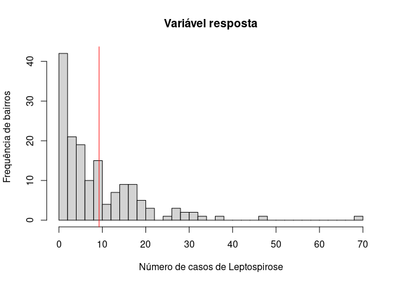

```r
hist(lepto$casos, ylab = "Frequência de bairros", xlab = "Número de casos de Leptospirose",
    main = "Variável resposta", nclass = 30)
abline(v = mean(lepto$casos, na.rm = T), col = "red")
```

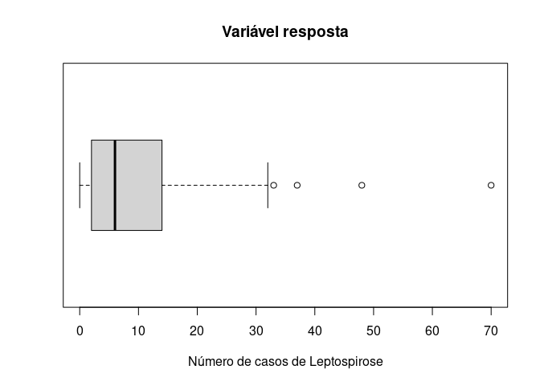

```r
boxplot(lepto$casos, xlab = "Número de casos de Leptospirose", main = "Variável resposta",
    horizontal = T)
```

```r
summary(lepto$casos)
```

```
   Min. 1st Qu.  Median    Mean 3rd Qu.    Max.
  0.000   2.000   6.000   9.256  14.000  70.000
```

```r
var(lepto$casos)
```

```
[1] 101.8693
```

- É possível observar uma distribuição no número de casos suspeitos de leptospirose na cidade d Rio de Janeiro/RJ pode ser classificada como sendo uma distribuição assimétrica a direita ou positiva.
- Podemos observar alguns bairros que apresentaram mais de $30$ casos durante esse período de estudo. Tais dados foram considerados como *outliers* superiores pelo *boxplot*.
- A média de casos de leptospirose no período para cada bairro foi de 9.26 casos. Durante o período, tiveram bairros que não ocorreram casos e bairros com até 70 casos.
- A variância dos casos foi de 101.87, configurando uma $Var(Y) > E(Y)$, que pode vir a se caracterizar uma superdispersão dos casos de leptospitose.

### Avaliação da correlação entre as variáveis quantitativas

```r
names(lepto)
```

```
 [1] "BAIRRO"       "CODBNUM"      "casos"        "pop2010"      "res2010"
 [6] "mordom"       "coleta_lixo"  "esgoto"       "txalfa"       "ids"
[11] "SemRenda"     "Renda"        "semrenda"     "semrenda_cat"
```

```r
# Matriz de correlação das vars quantitativas
cor(lepto[c(3, 6:10, 12:13)])
```

```
                  casos     mordom coleta_lixo      esgoto     txalfa
casos        1.00000000  0.2368884 -0.19218112 -0.05663643 -0.2280554
mordom       0.23688843  1.0000000 -0.31144698 -0.40271438 -0.6023122
coleta_lixo -0.19218112 -0.3114470  1.00000000  0.02689428  0.3585014
esgoto      -0.05663643 -0.4027144  0.02689428  1.00000000  0.4233059
txalfa      -0.22805535 -0.6023122  0.35850145  0.42330588  1.0000000
ids         -0.28569260 -0.7508296  0.28654558  0.53259017  0.7651973
Renda       -0.27884147 -0.6867909  0.22735813  0.19510264  0.5266447
semrenda     0.21821539  0.5984012 -0.24936774 -0.51453205 -0.5242208
                   ids      Renda   semrenda
casos       -0.2856926 -0.2788415  0.2182154
mordom      -0.7508296 -0.6867909  0.5984012
coleta_lixo  0.2865456  0.2273581 -0.2493677
esgoto       0.5325902  0.1951026 -0.5145321
txalfa       0.7651973  0.5266447 -0.5242208
ids          1.0000000  0.8394896 -0.5986088
Renda        0.8394896  1.0000000 -0.4392556
semrenda    -0.5986088 -0.4392556  1.0000000
```

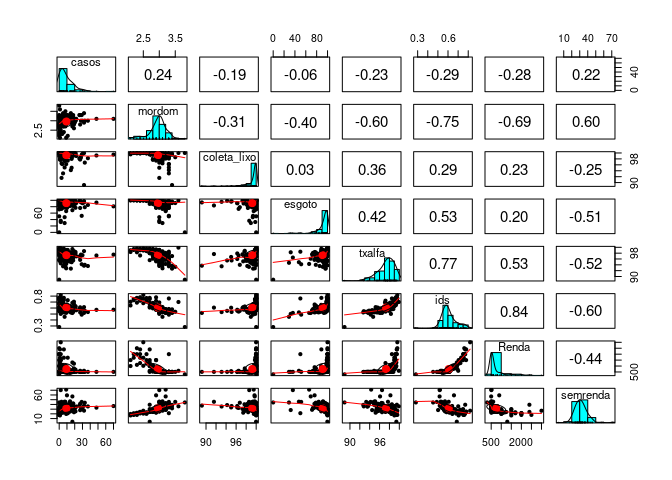

```r
# Forma gráfica
library(psych)
pairs.panels(lepto[c(3, 6:10, 12:13)])
```

- Podemos observar que a maioria das variáveis explicativas apresentam uma correlação com a ocorrência de casos de leptopirose, com exceção do percentual de domicílios com esgotamento sanitário adequado.

## Modelos bivariados com todas as variáveis selecionadas (supondo $\alpha = 20\%$)

```r
m1 <- glm(casos ~ offset(log(pop2010)) + mordom, family = "poisson", data = lepto)
m2 <- glm(casos ~ offset(log(pop2010)) + coleta_lixo, family = "poisson", data = lepto)
m3 <- glm(casos ~ offset(log(pop2010)) + esgoto, family = "poisson", data = lepto)
m4 <- glm(casos ~ offset(log(pop2010)) + txalfa, family = "poisson", data = lepto)
m5 <- glm(casos ~ offset(log(pop2010)) + ids, family = "poisson", data = lepto)
m6 <- glm(casos ~ offset(log(pop2010)) + Renda, family = "poisson", data = lepto)
m7 <- glm(casos ~ offset(log(pop2010)) + semrenda, family = "poisson", data = lepto)
m8 <- glm(casos ~ offset(log(pop2010)) + semrenda_cat, family = "poisson", data = lepto)

summary(m1)
```

```
Call:
glm(formula = casos ~ offset(log(pop2010)) + mordom, family = "poisson",
    data = lepto)

Deviance Residuals:
    Min       1Q   Median       3Q      Max
-5.5760  -1.3398  -0.2688   0.9450   7.6846

Coefficients:
            Estimate Std. Error z value Pr(>|z|)
(Intercept) -11.6923     0.3422  -34.17   <2e-16 ***
mordom        1.1317     0.1126   10.05   <2e-16 ***
---
Signif. codes:  0 '***' 0.001 '**' 0.01 '*' 0.05 '.' 0.1 ' ' 1

(Dispersion parameter for poisson family taken to be 1)

    Null deviance: 807.32  on 155  degrees of freedom
Residual deviance: 693.42  on 154  degrees of freedom
AIC: 1224.6

Number of Fisher Scoring iterations: 5
```

```r
summary(m2)
```

```
Call:
glm(formula = casos ~ offset(log(pop2010)) + coleta_lixo, family = "poisson",
    data = lepto)

Deviance Residuals:
    Min       1Q   Median       3Q      Max
-5.9763  -1.2205  -0.2424   1.1453   6.5188

Coefficients:
            Estimate Std. Error z value Pr(>|z|)
(Intercept)   3.1845     1.3457   2.366    0.018 *
coleta_lixo  -0.1159     0.0136  -8.523   <2e-16 ***
---
Signif. codes:  0 '***' 0.001 '**' 0.01 '*' 0.05 '.' 0.1 ' ' 1

(Dispersion parameter for poisson family taken to be 1)

    Null deviance: 807.32  on 155  degrees of freedom
Residual deviance: 748.90  on 154  degrees of freedom
AIC: 1280.1

Number of Fisher Scoring iterations: 5
```

```r
summary(m3)
```

```
Call:
glm(formula = casos ~ offset(log(pop2010)) + esgoto, family = "poisson",
    data = lepto)

Deviance Residuals:
    Min       1Q   Median       3Q      Max
-4.8706  -1.2709  -0.3673   1.1615   7.3144

Coefficients:
            Estimate Std. Error z value Pr(>|z|)
(Intercept) -7.24149    0.21240 -34.094  < 2e-16 ***
esgoto      -0.01170    0.00234  -4.998 5.78e-07 ***
---
Signif. codes:  0 '***' 0.001 '**' 0.01 '*' 0.05 '.' 0.1 ' ' 1

(Dispersion parameter for poisson family taken to be 1)

    Null deviance: 807.32  on 155  degrees of freedom
Residual deviance: 784.53  on 154  degrees of freedom
AIC: 1315.7

Number of Fisher Scoring iterations: 5
```

```r
summary(m4)
```

```
Call:
glm(formula = casos ~ offset(log(pop2010)) + txalfa, family = "poisson",
    data = lepto)

Deviance Residuals:
    Min       1Q   Median       3Q      Max
-6.8448  -1.4910  -0.2163   1.1503   6.9418

Coefficients:
            Estimate Std. Error z value Pr(>|z|)
(Intercept)  3.52265    1.45496   2.421   0.0155 *
txalfa      -0.12184    0.01502  -8.114 4.89e-16 ***
---
Signif. codes:  0 '***' 0.001 '**' 0.01 '*' 0.05 '.' 0.1 ' ' 1

(Dispersion parameter for poisson family taken to be 1)

    Null deviance: 807.32  on 155  degrees of freedom
Residual deviance: 744.81  on 154  degrees of freedom
AIC: 1276

Number of Fisher Scoring iterations: 5
```

```r
summary(m5)
```

```
Call:
glm(formula = casos ~ offset(log(pop2010)) + ids, family = "poisson",
    data = lepto)

Deviance Residuals:
    Min       1Q   Median       3Q      Max
-5.6069  -1.2232  -0.1421   1.1249   7.2836

Coefficients:
            Estimate Std. Error z value Pr(>|z|)
(Intercept)  -5.2309     0.2721  -19.23   <2e-16 ***
ids          -5.1659     0.4628  -11.16   <2e-16 ***
---
Signif. codes:  0 '***' 0.001 '**' 0.01 '*' 0.05 '.' 0.1 ' ' 1

(Dispersion parameter for poisson family taken to be 1)

    Null deviance: 807.32  on 155  degrees of freedom
Residual deviance: 665.30  on 154  degrees of freedom
AIC: 1196.5

Number of Fisher Scoring iterations: 5
```

```r
summary(m6)
```

```
Call:
glm(formula = casos ~ offset(log(pop2010)) + Renda, family = "poisson",
    data = lepto)

Deviance Residuals:
    Min       1Q   Median       3Q      Max
-4.9885  -1.1935  -0.2621   0.9327   6.7825

Coefficients:
              Estimate Std. Error z value Pr(>|z|)
(Intercept) -7.607e+00  6.452e-02 -117.91   <2e-16 ***
Renda       -1.044e-03  9.697e-05  -10.77   <2e-16 ***
---
Signif. codes:  0 '***' 0.001 '**' 0.01 '*' 0.05 '.' 0.1 ' ' 1

(Dispersion parameter for poisson family taken to be 1)

    Null deviance: 807.32  on 155  degrees of freedom
Residual deviance: 631.41  on 154  degrees of freedom
AIC: 1162.6

Number of Fisher Scoring iterations: 5
```

```r
summary(m7)
```

```
Call:
glm(formula = casos ~ offset(log(pop2010)) + semrenda, family = "poisson",
    data = lepto)

Deviance Residuals:
    Min       1Q   Median       3Q      Max
-4.9338  -1.3232  -0.1434   1.1315   7.4526

Coefficients:
             Estimate Std. Error z value Pr(>|z|)
(Intercept) -9.219955   0.111509 -82.683   <2e-16 ***
semrenda     0.027829   0.003201   8.693   <2e-16 ***
---
Signif. codes:  0 '***' 0.001 '**' 0.01 '*' 0.05 '.' 0.1 ' ' 1

(Dispersion parameter for poisson family taken to be 1)

    Null deviance: 807.32  on 155  degrees of freedom
Residual deviance: 735.46  on 154  degrees of freedom
AIC: 1266.6

Number of Fisher Scoring iterations: 5
```

```r
summary(m8)
```

```
Call:
glm(formula = casos ~ offset(log(pop2010)) + semrenda_cat, family = "poisson",
    data = lepto)

Deviance Residuals:
    Min       1Q   Median       3Q      Max
-4.7972  -1.2706  -0.1249   1.0940   7.8144

Coefficients:
                     Estimate Std. Error  z value Pr(>|z|)
(Intercept)           -8.5667     0.0500 -171.335  < 2e-16 ***
semrenda_catMaior 30   0.3868     0.0588    6.579 4.75e-11 ***
---
Signif. codes:  0 '***' 0.001 '**' 0.01 '*' 0.05 '.' 0.1 ' ' 1

(Dispersion parameter for poisson family taken to be 1)

    Null deviance: 807.32  on 155  degrees of freedom
Residual deviance: 761.69  on 154  degrees of freedom
AIC: 1292.8

Number of Fisher Scoring iterations: 5
```

### Criando uma função para calcular a razão de taxas dos coeficientes + respetivos IC’s a $95\%$

```r
# Criando a funcao

glm.RR <- function(model) {
    glm.coeffs <- coef(summary(model))
    L.CI <- exp(glm.coeffs[, 1] - 1.96 * glm.coeffs[, 2])
    RR <- exp(glm.coeffs[, 1])
    U.CI <- exp(glm.coeffs[, 1] + 1.96 * glm.coeffs[, 2])
    glm.RR <- cbind(RR, L.CI, U.CI)
    round(glm.RR, 3)
}
```

```r
glm.RR(m1)
```

```
               RR  L.CI  U.CI
(Intercept) 0.000 0.000 0.000
mordom      3.101 2.487 3.867
```

```r
glm.RR(m2)
```

```
                RR  L.CI    U.CI
(Intercept) 24.154 1.728 337.654
coleta_lixo  0.891 0.867   0.915
```

```r
glm.RR(m3)
```

```
               RR  L.CI  U.CI
(Intercept) 0.001 0.000 0.001
esgoto      0.988 0.984 0.993
```

```r
glm.RR(m4)
```

```
                RR  L.CI    U.CI
(Intercept) 33.874 1.956 586.613
txalfa       0.885 0.860   0.912
```

```r
glm.RR(m5)
```

```
               RR  L.CI  U.CI
(Intercept) 0.005 0.003 0.009
ids         0.006 0.002 0.014
```

```r
glm.RR(m6)
```

```
               RR  L.CI  U.CI
(Intercept) 0.000 0.000 0.001
Renda       0.999 0.999 0.999
```

```r
glm.RR(m7)
```

```
               RR  L.CI  U.CI
(Intercept) 0.000 0.000 0.000
semrenda    1.028 1.022 1.035
```

```r
glm.RR(m8)
```

```
                        RR  L.CI  U.CI
(Intercept)          0.000 0.000 0.000
semrenda_catMaior 30 1.472 1.312 1.652
```

Podemos interpretar os modelos bivariados cujos preditores foram significativas dessa forma:

**m1)** A cada aumento de um morador por domicílio, o número médio de casos aumenta em 3 vezes $(RP = 3,1)$

**m2)** Temos uma redução na média de casos na ordem de $0,89$ ou de $[(1-0,89) \times 100 = 11\%$ para cada aumento percentual de domicílios com coleta de lixo regular.

**m3)** Temos uma redução na média de casos na ordem de $0,98$ ou de $[(1-0,98) \times 100 = 2\%$ para cada aumento percentual de percentual de domicílios com esgotamento sanitário adequado.

**m4)** Temos uma redução na média de casos na ordem de $0,88$ ou de $[(1-0,88) \times 100 = 12\%$ para cada aumento percentual de alfabetizados.

**m5)** Temos uma redução na média de casos na ordem de $0,006$ ou de $[(1-0,006) \times 100 = 99\%$ para cada aumento de unidade do índice de desemvolvimento social.

**m7)** A cada aumento percentual de pessoal sem renda declarada, o número médio de casos aumenta em $1,028$ vezes.

**m8)** Esse resultado indica os bairros com um percentual maior que $30\%$ de pessoas sem renda declarada, apresentam uma média de casos de leptospirose $1,472$ vezes maior que os bairros com um percentual menor que $30\%$ de pessoas sem renda declarada.

- Como todas as variáveis foram significativas, iremos rodar um modelo com todas elas e verificar quais foram significativas. Vamos utilizar a variável sem renda de forma categórica.

```r
modelo.vazio <- glm(casos ~ 1, family = "poisson", data = lepto)
modelo.cheio <- glm(casos ~ offset(log(pop2010)) + mordom + coleta_lixo + esgoto +
    txalfa + ids + Renda + semrenda_cat, family = "poisson", data = lepto)

summary(modelo.cheio)
```

```
Call:
glm(formula = casos ~ offset(log(pop2010)) + mordom + coleta_lixo +
    esgoto + txalfa + ids + Renda + semrenda_cat, family = "poisson",
    data = lepto)

Deviance Residuals:
    Min       1Q   Median       3Q      Max
-5.3099  -1.0408  -0.3176   0.9333   6.2324

Coefficients:
                       Estimate Std. Error z value Pr(>|z|)
(Intercept)           1.1085465  2.6339352   0.421   0.6738
mordom               -0.2280962  0.2404724  -0.949   0.3429
coleta_lixo          -0.0997583  0.0179809  -5.548 2.89e-08 ***
esgoto               -0.0072308  0.0035343  -2.046   0.0408 *
txalfa                0.0239023  0.0286615   0.834   0.4043
ids                   0.5468677  1.7708922   0.309   0.7575
Renda                -0.0011930  0.0002097  -5.691 1.27e-08 ***
semrenda_catMaior 30 -0.0592315  0.0794829  -0.745   0.4561
---
Signif. codes:  0 '***' 0.001 '**' 0.01 '*' 0.05 '.' 0.1 ' ' 1

(Dispersion parameter for poisson family taken to be 1)

    Null deviance: 807.32  on 155  degrees of freedom
Residual deviance: 601.02  on 148  degrees of freedom
AIC: 1144.2

Number of Fisher Scoring iterations: 5
```

```r
glm.RR(modelo.cheio)
```

```
                        RR  L.CI    U.CI
(Intercept)          3.030 0.017 529.038
mordom               0.796 0.497   1.275
coleta_lixo          0.905 0.874   0.938
esgoto               0.993 0.986   1.000
txalfa               1.024 0.968   1.083
ids                  1.728 0.054  55.580
Renda                0.999 0.998   0.999
semrenda_catMaior 30 0.942 0.807   1.101
```

- Como somente as variáveis coleta de lixo, esgoto e a renda foram significativas, ajustaremos um modelos com apenas essas variáveis.

```r
modelo.manual <- glm(casos ~ offset(log(pop2010)) + coleta_lixo + esgoto + Renda,
    family = "poisson", data = lepto)

summary(modelo.manual)
```

```
Call:
glm(formula = casos ~ offset(log(pop2010)) + coleta_lixo + esgoto +
    Renda, family = "poisson", data = lepto)

Deviance Residuals:
    Min       1Q   Median       3Q      Max
-5.5265  -1.0766  -0.3182   0.9044   6.5748

Coefficients:
              Estimate Std. Error z value Pr(>|z|)
(Intercept)  2.596e-01  1.492e+00   0.174    0.862
coleta_lixo -7.718e-02  1.490e-02  -5.180 2.21e-07 ***
esgoto      -3.260e-03  2.622e-03  -1.243    0.214
Renda       -9.322e-04  9.968e-05  -9.352  < 2e-16 ***
---
Signif. codes:  0 '***' 0.001 '**' 0.01 '*' 0.05 '.' 0.1 ' ' 1

(Dispersion parameter for poisson family taken to be 1)

    Null deviance: 807.32  on 155  degrees of freedom
Residual deviance: 606.89  on 152  degrees of freedom
AIC: 1142

Number of Fisher Scoring iterations: 5
```

```r
glm.RR(modelo.manual)
```

```
               RR  L.CI   U.CI
(Intercept) 1.296 0.070 24.151
coleta_lixo 0.926 0.899  0.953
esgoto      0.997 0.992  1.002
Renda       0.999 0.999  0.999
```

- Esgoto não foi mais significativo.

```r
modelo.manual2 <- glm(casos ~ offset(log(pop2010)) + coleta_lixo + Renda, family = "poisson",
    data = lepto)

summary(modelo.manual2)
```

```
Call:
glm(formula = casos ~ offset(log(pop2010)) + coleta_lixo + Renda,
    family = "poisson", data = lepto)

Deviance Residuals:
    Min       1Q   Median       3Q      Max
-5.5865  -1.0704  -0.3004   0.9290   6.4808

Coefficients:
              Estimate Std. Error z value Pr(>|z|)
(Intercept) -1.083e-01  1.458e+00  -0.074    0.941
coleta_lixo -7.626e-02  1.483e-02  -5.141 2.73e-07 ***
Renda       -9.608e-04  9.735e-05  -9.869  < 2e-16 ***
---
Signif. codes:  0 '***' 0.001 '**' 0.01 '*' 0.05 '.' 0.1 ' ' 1

(Dispersion parameter for poisson family taken to be 1)

    Null deviance: 807.32  on 155  degrees of freedom
Residual deviance: 608.40  on 153  degrees of freedom
AIC: 1141.6

Number of Fisher Scoring iterations: 5
```

```r
glm.RR(modelo.manual2)
```

```
               RR  L.CI   U.CI
(Intercept) 0.897 0.052 15.619
coleta_lixo 0.927 0.900  0.954
Renda       0.999 0.999  0.999
```

# Ajustando o modelo de forma automática

```r
library(MASS)
m_stepwise <- stepAIC(modelo.cheio, scope = list(upper = modelo.cheio, lower = modelo.vazio),
    direction = "both")
```

```
Start:  AIC=1144.17
casos ~ offset(log(pop2010)) + mordom + coleta_lixo + esgoto +
    txalfa + ids + Renda + semrenda_cat

               Df Deviance    AIC
- ids           1   601.11 1142.3
- semrenda_cat  1   601.57 1142.7
- txalfa        1   601.72 1142.9
- mordom        1   601.91 1143.1
<none>              601.02 1144.2
- esgoto        1   605.11 1146.3
- coleta_lixo   1   628.99 1170.2
- Renda         1   635.32 1176.5

Step:  AIC=1142.27
casos ~ mordom + coleta_lixo + esgoto + txalfa + Renda + semrenda_cat +
    offset(log(pop2010))

               Df Deviance    AIC
- semrenda_cat  1   601.77 1140.9
- mordom        1   602.40 1141.6
- txalfa        1   602.66 1141.8
<none>              601.11 1142.3
+ ids           1   601.02 1144.2
- esgoto        1   605.96 1145.1
- coleta_lixo   1   629.08 1168.2
- Renda         1   677.35 1216.5

Step:  AIC=1140.93
casos ~ mordom + coleta_lixo + esgoto + txalfa + Renda + offset(log(pop2010))

               Df Deviance    AIC
- txalfa        1   603.41 1140.6
<none>              601.77 1140.9
- mordom        1   604.13 1141.3
+ semrenda_cat  1   601.11 1142.3
+ ids           1   601.57 1142.7
- esgoto        1   606.10 1143.3
- coleta_lixo   1   629.52 1166.7
- Renda         1   678.09 1215.2

Step:  AIC=1140.57
casos ~ mordom + coleta_lixo + esgoto + Renda + offset(log(pop2010))

               Df Deviance    AIC
<none>              603.41 1140.6
+ txalfa        1   601.77 1140.9
+ ids           1   602.18 1141.3
+ semrenda_cat  1   602.66 1141.8
- esgoto        1   606.73 1141.9
- mordom        1   606.89 1142.0
- coleta_lixo   1   630.26 1165.4
- Renda         1   678.10 1213.3
```

```r
summary(m_stepwise)
```

```
Call:
glm(formula = casos ~ mordom + coleta_lixo + esgoto + Renda +
    offset(log(pop2010)), family = "poisson", data = lepto)

Deviance Residuals:
    Min       1Q   Median       3Q      Max
-5.4326  -1.0364  -0.3200   0.9633   6.2917

Coefficients:
              Estimate Std. Error z value Pr(>|z|)
(Intercept)  2.9031191  2.0486372   1.417   0.1565
mordom      -0.3780256  0.2021129  -1.870   0.0614 .
coleta_lixo -0.0894033  0.0162370  -5.506 3.67e-08 ***
esgoto      -0.0051826  0.0027934  -1.855   0.0636 .
Renda       -0.0011220  0.0001452  -7.727 1.10e-14 ***
---
Signif. codes:  0 '***' 0.001 '**' 0.01 '*' 0.05 '.' 0.1 ' ' 1

(Dispersion parameter for poisson family taken to be 1)

    Null deviance: 807.32  on 155  degrees of freedom
Residual deviance: 603.41  on 151  degrees of freedom
AIC: 1140.6

Number of Fisher Scoring iterations: 5
```

$$y_i | x_{i1}, x_{i2}, \dots, x_{ik} \sim \text{Poisson} (\lambda_i)$$

$$log(\lambda_i) = offset(pop2010_i) + 2,903 - 0,378 mordom_i - 0,089 coleta.lixo_i - 0,005 esgoto - 0,001 renda$$

```r
glm.RR(m_stepwise)
```

```
                RR  L.CI     U.CI
(Intercept) 18.231 0.329 1010.750
mordom       0.685 0.461    1.018
coleta_lixo  0.914 0.886    0.944
esgoto       0.995 0.989    1.000
Renda        0.999 0.999    0.999
```

## O que é a *Deviance* ou função desvio ?

- A *deviance* é uma métrica que está relacionada ao erro, quanto menor desvio significa que o modelo se ajusta melhor aos dados.
- Quanto maior o desvio, pior o modelo se ajusta aos dados em comparação ao melhor modelo (modelo saturado).
- *Deviance* é uma estatística de qualidade de ajuste para um modelo frequentemente usado para testes de hipóteses.

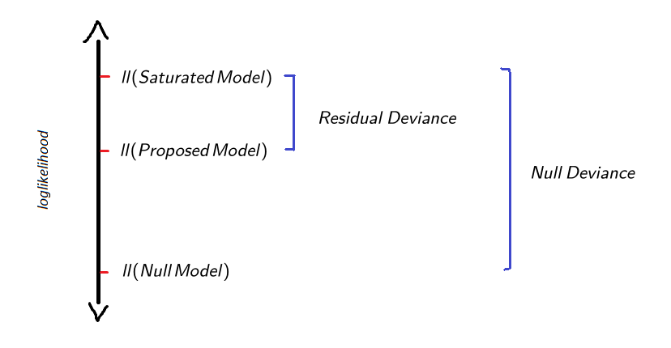

Temos então:

$$\text{Null Deviance} = 2 \times [ll(\text{Saturated Model}) - ll(\text{Null Model})]$$

$$\text{Residual Deviance} = 2 \times [ll(\text{Saturated Model}) - ll(\text{Proposed Model})]$$

```r
anova(modelo.manual2, m_stepwise, test = "Chisq")
```

```
Analysis of Deviance Table

Model 1: casos ~ offset(log(pop2010)) + coleta_lixo + Renda
Model 2: casos ~ mordom + coleta_lixo + esgoto + Renda + offset(log(pop2010))
  Resid. Df Resid. Dev Df Deviance Pr(>Chi)
1       153     608.40
2       151     603.41  2   4.9886  0.08255 .
---
Signif. codes:  0 '***' 0.001 '**' 0.01 '*' 0.05 '.' 0.1 ' ' 1
```

```r
# Ou pelo teste da razao de verossimilhança

library("lmtest")
lrtest(modelo.manual2, m_stepwise)
```

```
Likelihood ratio test

Model 1: casos ~ offset(log(pop2010)) + coleta_lixo + Renda
Model 2: casos ~ mordom + coleta_lixo + esgoto + Renda + offset(log(pop2010))
  #Df  LogLik Df  Chisq Pr(>Chisq)
1   3 -567.78
2   5 -565.28  2 4.9886    0.08255 .
---
Signif. codes:  0 '***' 0.001 '**' 0.01 '*' 0.05 '.' 0.1 ' ' 1
```

- Através da análise de variância, ao nível de $\alpha = 5\%$, o modelo manual 2 não apresenta diferença em relação ao modelo ajustado de forma automática. Mas de qualquer forma a *deviance* $(603,41)$ do modelo ajustado de forma automática é menor. E pelo teste de razão de verossimilhança, a *verossimilhança* $(-565,28)$ do modelo automático é maior. Por isso vamos ficar com o modelo automático.

## Deviance ou estatística *D*

$$D = \text{Deviance}_{residual} \sim \chi^2_{1-\alpha; n-(p+1)}$$

```r
m_stepwise$deviance
```

```
[1] 603.4088
```

```r
pvalor <- pchisq(m_stepwise$deviance, df = m_stepwise$df.residual, lower.tail = FALSE)
pvalor
```

```
[1] 2.325239e-55
```

## Estatística de Pearson

$$\chi^2 = \sum_{i=1}^n \dfrac{(y_i - \hat{\lambda}_i)^2}{\hat{\lambda}_i}$$

$$\chi^2 \sim \chi^2_{1-\alpha; n-(p+1)}$$

```r
pearson <- sum((lepto$casos - m_stepwise$fitted.values)^2/m_stepwise$fitted.values)
pearson
```

```
[1] 782.1701
```

```r
pvalor <- pchisq(pearson, df = m_stepwise$df.residual, lower.tail = FALSE)
pvalor
```

```
[1] 8.188935e-86
```

- Como a hipótese nula $(H_0)$ é que nosso modelo está especificado corretamente e como o $p-valor < 0,001$, temos fortes evidências de dizer que o modelo não se ajusta muito bem aos nossos dados.

### Estatística $D^2$

- Calcula a quantidade da deviance explicada pelo modelo, ou seja, é a proporção do desvio na variável resposta explicada pelo modelo.

$$D^2 = 1 - \dfrac{\text{Deviance}_{residual}}{\text{Deviance}_{nula}}$$

```r
Dsquared <- 1 - (m_stepwise$deviance/m_stepwise$null.deviance)
Dsquared
```

```
[1] 0.2525752
```

- O modelo está conseguindo explicar $D^2 =$ 25.26 $\%$ da ocorrência dos casos de leptospirose.

### Pseudo $R^2$ de McFadden

- A interpretação é semelhante ao do $R^2$ do modelo de regressão linear.

$$R^2_{MF} = 1 - \dfrac{LL \text{ (modelo proposto)}}{LL \text{ (modelo nulo)}}$$

```r
pseudoR2 <- as.numeric(1 - logLik(m_stepwise)/logLik(modelo.vazio))
pseudoR2
```

```
[1] 0.423211
```

- O modelo consegue explicar somente 42.32 $\%$ da variabilidade da ocorrência dos casos de leptospirose.

## Análise dos resíduos

[figure not shown]

```r
par(mfrow = c(2, 1))
plot(m_stepwise$fitted.values, rstandard(m_stepwise), xlab = "Valores Preditos",
    ylab = "Resíduos padronizados", main = "", las = 1)
abline(h = 0, lwd = 1, lty = 2, col = "red")
plot(m_stepwise$fitted.values, rstudent(m_stepwise), xlab = "Valores Preditos", ylab = "Resíduos studentizado",
    main = "", las = 1)
abline(h = 0, lwd = 1, lty = 2, col = "red")
```

## Análise dos resíduos

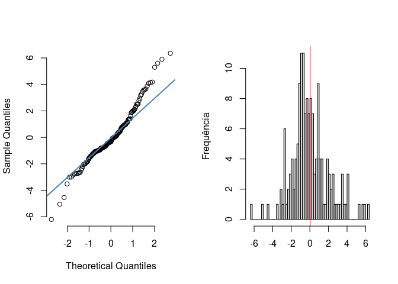

```r
par(mfrow = c(1, 2))
qqnorm(rstandard(m_stepwise), pch = 1, main = "", frame = FALSE)
qqline(rstandard(m_stepwise), col = "steelblue", lwd = 2)

hist(rstandard(m_stepwise), ylab = "Frequência", xlab = "", main = "", nclass = 70)
abline(v = mean(rstandard(m_stepwise), na.rm = T), col = "red")
```

## Investigando a superdispersão

```r
pearson <- sum((lepto$casos - m_stepwise$fitted.values)^2/m_stepwise$fitted.values)
phi <- pearson/m_stepwise$df.residual
phi
```

```
[1] 5.179935
```

- Como já vimo anteriomente que a média de casos (9.26) e menor que a variância de casos (101.87), o valor do parâmetro de dispersão será $\phi =$ 5.18, indicando uma superdispersão para nos dados.

## Modelo Quasipoisson

```r
m_quasi <- glm(casos ~ offset(log(pop2010)) + mordom + coleta_lixo + esgoto + Renda,
    family = "quasipoisson", lepto)

summary(m_quasi)
```

```
Call:
glm(formula = casos ~ offset(log(pop2010)) + mordom + coleta_lixo +
    esgoto + Renda, family = "quasipoisson", data = lepto)

Deviance Residuals:
    Min       1Q   Median       3Q      Max
-5.4326  -1.0364  -0.3200   0.9633   6.2917

Coefficients:
              Estimate Std. Error t value Pr(>|t|)
(Intercept)  2.9031191  4.6625896   0.623 0.534460
mordom      -0.3780256  0.4599982  -0.822 0.412488
coleta_lixo -0.0894033  0.0369546  -2.419 0.016740 *
esgoto      -0.0051826  0.0063577  -0.815 0.416258
Renda       -0.0011220  0.0003305  -3.395 0.000877 ***
---
Signif. codes:  0 '***' 0.001 '**' 0.01 '*' 0.05 '.' 0.1 ' ' 1

(Dispersion parameter for quasipoisson family taken to be 5.179935)

    Null deviance: 807.32  on 155  degrees of freedom
Residual deviance: 603.41  on 151  degrees of freedom
AIC: NA

Number of Fisher Scoring iterations: 5
```

```r
summary(m_stepwise)
```

```
Call:
glm(formula = casos ~ mordom + coleta_lixo + esgoto + Renda +
    offset(log(pop2010)), family = "poisson", data = lepto)

Deviance Residuals:
    Min       1Q   Median       3Q      Max
-5.4326  -1.0364  -0.3200   0.9633   6.2917

Coefficients:
              Estimate Std. Error z value Pr(>|z|)
(Intercept)  2.9031191  2.0486372   1.417   0.1565
mordom      -0.3780256  0.2021129  -1.870   0.0614 .
coleta_lixo -0.0894033  0.0162370  -5.506 3.67e-08 ***
esgoto      -0.0051826  0.0027934  -1.855   0.0636 .
Renda       -0.0011220  0.0001452  -7.727 1.10e-14 ***
---
Signif. codes:  0 '***' 0.001 '**' 0.01 '*' 0.05 '.' 0.1 ' ' 1

(Dispersion parameter for poisson family taken to be 1)

    Null deviance: 807.32  on 155  degrees of freedom
Residual deviance: 603.41  on 151  degrees of freedom
AIC: 1140.6

Number of Fisher Scoring iterations: 5
```

## Modelo binomial negativo ([link](https://stats.idre.ucla.edu/r/dae/negative-binomial-regression/))

- Vamos ajustar um Modelo Linear Generalizado com distribuição Binomial negativa com função de ligação logarítmica. A expressão do modelo é igual ao do modelo Poisson, porém a distribuição da resposta tem forma diferente.
- Vale lembrar que o modelo de regressão Binomial Negativo estima um parâmetro de dispersão que não existe no modelo Poisson.

$$y_i | x_{i1}, x_{i2}, \dots, x_{ik} \sim \text{Binomial Negativa} (\lambda_i , \phi)$$

$$log(\lambda_i) = offset(pop2010_i) - 1,525 + 0,18 mordom_i -0,058 coleta.lixo_i - 0.007 esgoto - 0.001 renda$$

```r
m_binomial.neg <- glm.nb(casos ~ offset(log(pop2010)) + mordom + coleta_lixo + esgoto +
    Renda, data = lepto)
summary(m_binomial.neg)
```

```
Call:
glm.nb(formula = casos ~ offset(log(pop2010)) + mordom + coleta_lixo +
    esgoto + Renda, data = lepto, init.theta = 2.877816821, link = log)

Deviance Residuals:
    Min       1Q   Median       3Q      Max
-2.4471  -0.8373  -0.3066   0.3043   3.1722

Coefficients:
              Estimate Std. Error z value Pr(>|z|)
(Intercept) -1.5253326  4.4543061  -0.342    0.732
mordom       0.1824737  0.3817967   0.478    0.633
coleta_lixo -0.0584066  0.0384394  -1.519    0.129
esgoto      -0.0072343  0.0054546  -1.326    0.185
Renda       -0.0010793  0.0002368  -4.558 5.17e-06 ***
---
Signif. codes:  0 '***' 0.001 '**' 0.01 '*' 0.05 '.' 0.1 ' ' 1

(Dispersion parameter for Negative Binomial(2.8778) family taken to be 1)

    Null deviance: 235.92  on 155  degrees of freedom
Residual deviance: 170.01  on 151  degrees of freedom
AIC: 895.47

Number of Fisher Scoring iterations: 1

              Theta:  2.878
          Std. Err.:  0.480

 2 x log-likelihood:  -883.466
```

```r
m_binomial.neg$deviance
```

```
[1] 170.0119
```

```r
pvalor <- pchisq(m_binomial.neg$deviance, df = m_binomial.neg$df.residual, lower.tail = FALSE)
pvalor
```

```
[1] 0.138035
```

- Como a hipótese nula $(H_0)$ é que nosso modelo está especificado corretamente e como o $p-valor > 0,05$, temos fortes evidências de dizer que o modelo se ajusta de forma adequada aos nossos dados.

## Estatística $D^2$

- Calcula a quantidade da deviance explicada pelo modelo, ou seja, é a proporção do desvio na variável resposta explicada pelo modelo.

$$D^2 = 1 - \dfrac{\text{Deviance}_{residual}}{\text{Deviance}_{nula}}$$

```r
Dsquared <- 1 - (m_binomial.neg$deviance/m_binomial.neg$null.deviance)
Dsquared
```

```
[1] 0.2793607
```

## Comparando o modelo de poisson com o binomial negativo

- Para seleção de modelos diversas medidas podem ser utilizadas, em especial vamos utilizar a verossimilhança e o AIC dos modelos.

```r
Ajuste = c("Modelo.Poisson", "Modelo.Binomial.Neg")
AIC = c(AIC(m_stepwise), AIC(m_binomial.neg))
BIC = c(BIC(m_stepwise), BIC(m_binomial.neg))
Verossimilhança = c(logLik(m_stepwise), logLik(m_binomial.neg))
data.frame(Ajuste, AIC, BIC, Verossimilhança)
```

```
               Ajuste      AIC       BIC Verossimilhança
1      Modelo.Poisson 1140.567 1155.8168       -565.2837
2 Modelo.Binomial.Neg  895.466  913.7652       -441.7330
```

- O modelo que apresentou menores valores para os AIC e BIC, e o valor da verossimilhança foi maior para o modelo Binomial Negativo. Adicionalmente, vamos verificar o comportamento dos gráfico meio Normais de probabilidades com envelopes simulados.
- Esses gráficos permitem verificar a adequação do modelo ajustado mesmo que os resíduos não tenham uma aproximação adequada com a distribuição Normal. Sendo assim, neste tipo de gráfico espera-se, para um modelo bem ajustado, os pontos (resíduos) dispersos aleatoriamente entre os limites do envelope.
- Deve-se ficar atento à presença de pontos fora dos limites do envelope ou ainda a pontos dentro dos limites porém apresentando padrões sistemáticos.

```r
library(hnp)
par(mfrow = c(1, 2))
hnp(m_stepwise, xlab = "Percentil da N(0,1)", ylab = "Resíduos", main = "QQplot - Modelo Poisson")
```

```
Poisson model
```

```
Negative binomial model (using MASS package)
```

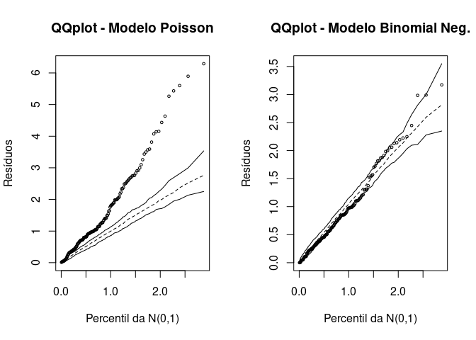

```r
hnp(m_binomial.neg, xlab = "Percentil da N(0,1)", ylab = "Resíduos", main = "QQplot - Modelo Binomial Neg.")
```

- Nota-se pelas medidas de qualidade de ajuste e o comportamento dos resíduos no gráfico a total falta de aderência à distribuição de Poison. Já para a distribuição da resposta para Binomial Negativa obteve-se um ajuste satisfatório.

## Medidas de Influência

Uma alternativa para verificação de medidas influentes está implementada no pacote car.

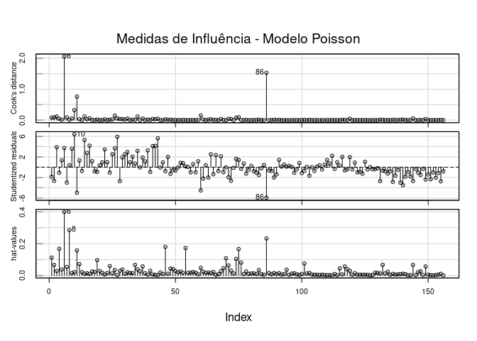

```r
library(car)
influenceIndexPlot(m_stepwise, vars = c("Cook", "Studentized", "hat"), main = "Medidas de Influência - Modelo Poisson")
```

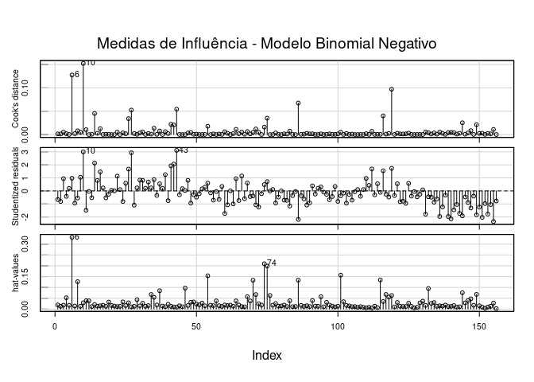

```r
influenceIndexPlot(m_binomial.neg, vars = c("Cook", "Studentized", "hat"), main = "Medidas de Influência - Modelo Binomial Negativo")
```

- O primeiro gráfico apresenta os valores da distância de Cook para cada observação. A distância de Cook é uma medida de diferença das estimativas dos parâmetros do modelo ao considerar e ao desconsiderar uma particular observação no ajuste.
- O segundo gráfico mostra os resíduos studentizados. Um modelo bem ajustado apresenta estes resíduos dispersos aleatóriamente em torno de 0, entre $-3$ e $3$ desvios.
- O terceiro gráfico mostra os valores dos pontos de alavanca ($h_{ii}$). Valores elevados são considerados potencialmente influentes. Os valores desses pontos de alavanca estão entre 0 e 1.